# EDA on IRIS Dataset

# Data Visualization

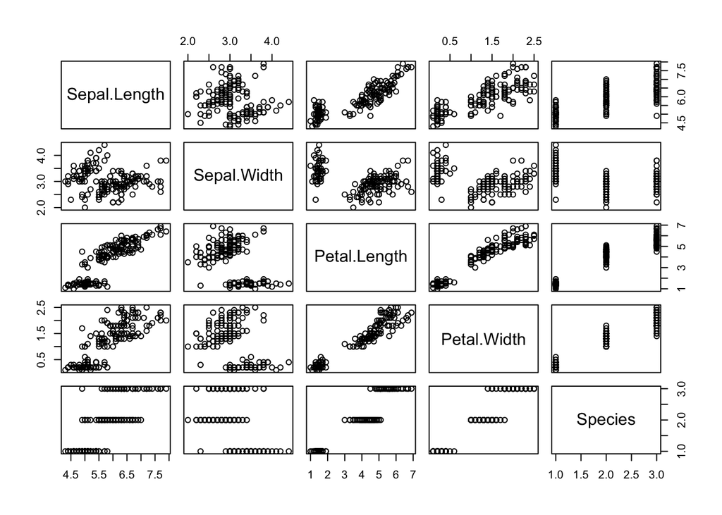

```r
# Visualization
plot(data)
```

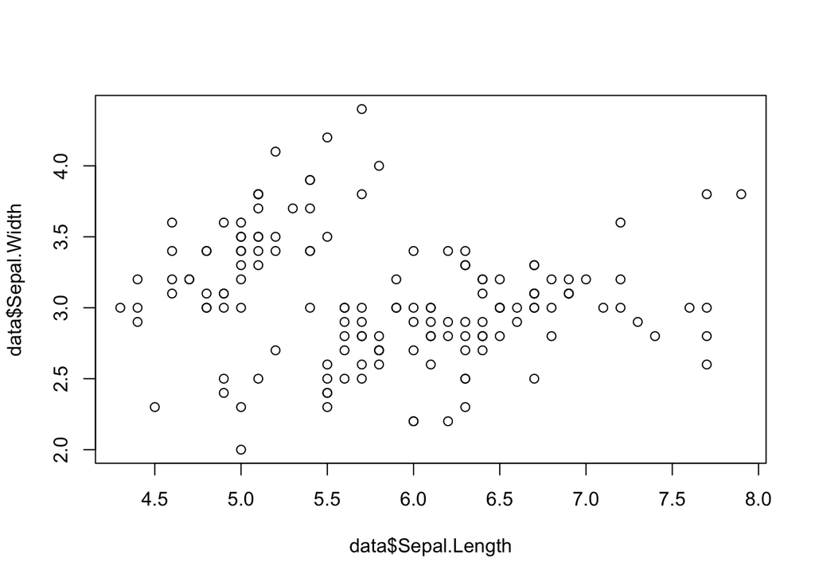

```r
plot(data$Sepal.Length,data$Sepal.Width)
```

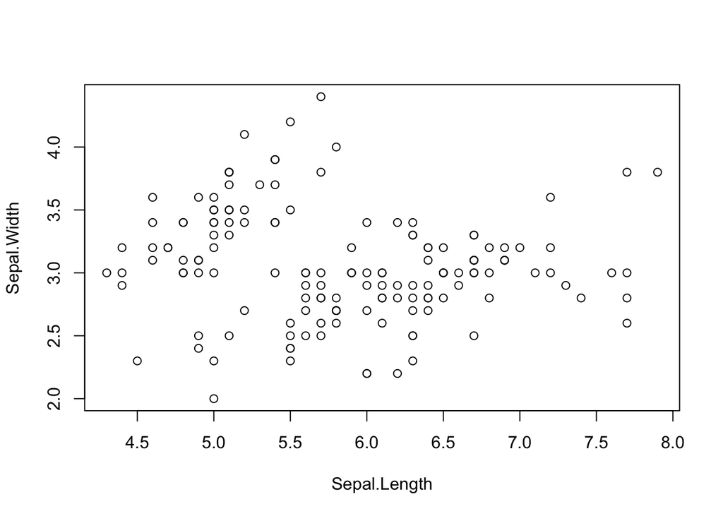

```r
# Visualization Another Way
tw=select(data,1:2)
plot(tw)
```

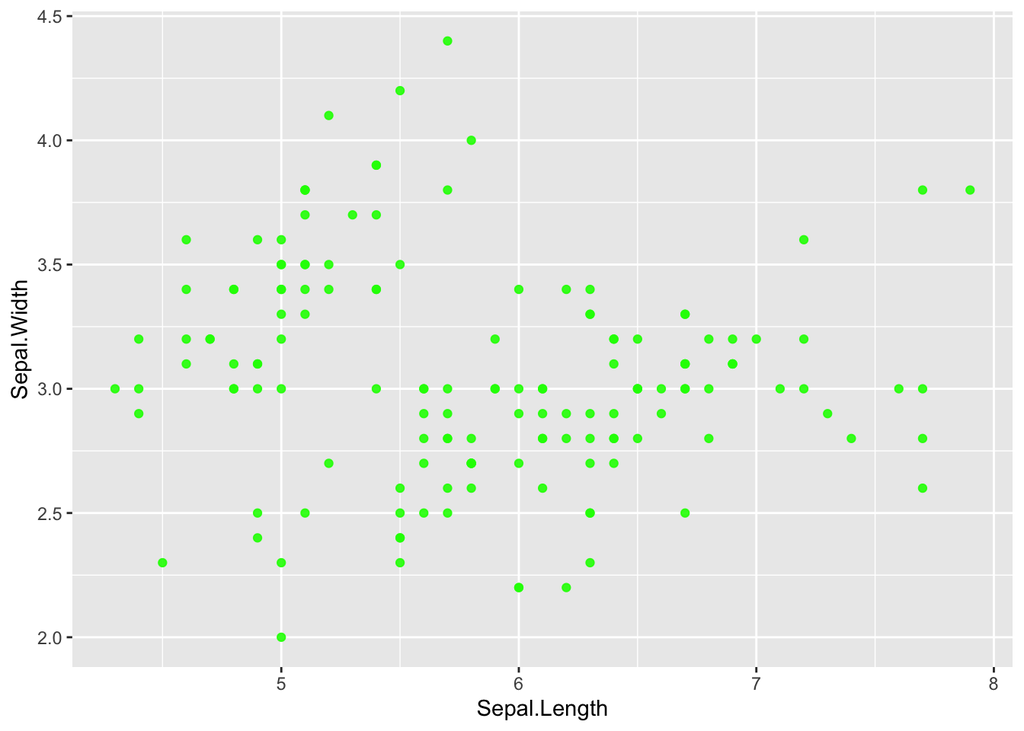

```r
ggplot(tw,mapping=aes(x=Sepal.Length,y=Sepal.Width))+geom_point(alpha=0.9,colour="green")
```

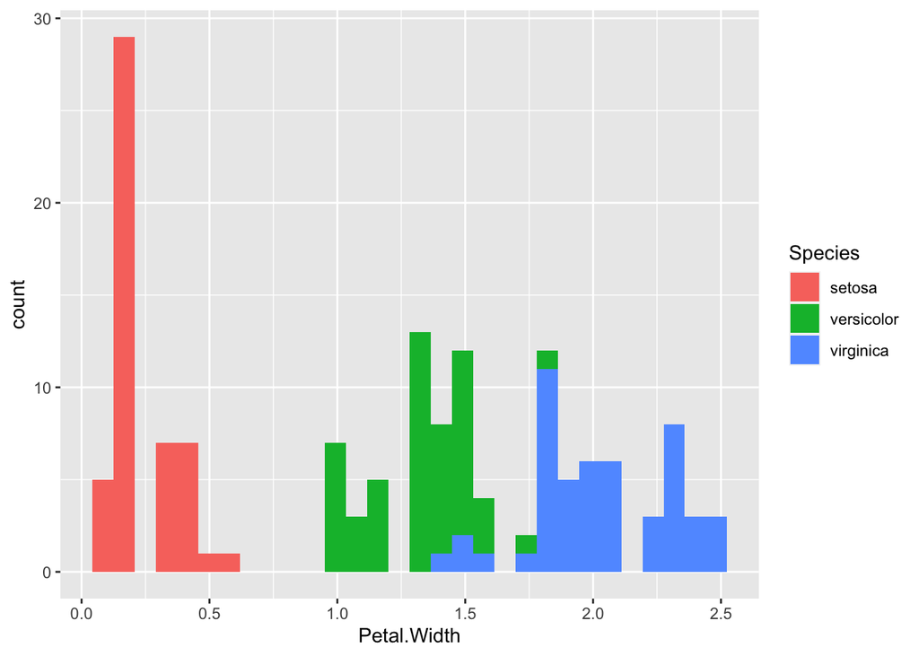

```r
## Visualization with Histogram
iris%>%
  ggplot(aes(x=Petal.Width, fill=Species))+
  geom_histogram()
```

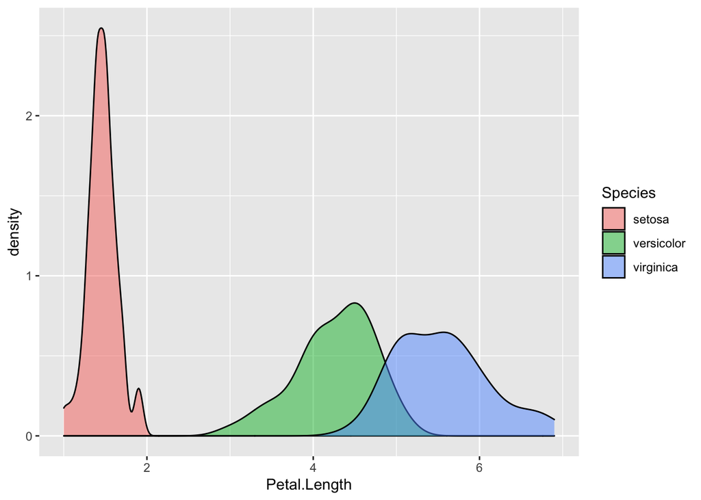

```r
iris%>%
    ggplot(aes(x=Petal.Length, fill=Species))+
    geom_density(alpha=0.5)
```

## Scatter Plots Scatter plots give us a good idea of how much one variable is affected by another. In other words, it is very helpful when we are trying to see if there is any correlation between two variables. As shown in Fig. 3, there is a high correlation between the sepal length and the sepal width of the Setosa iris flowers, while the correlation is somewhat less high for the Virginica and Versicolor flowers: the data points are more spread out over the graph and do not form a cluster like shown in the case of the Setosa flowers. The scatter plot that maps the petal length and the petal width displayed as Fig. 4 tells a similar story: The graph indicates a positive correlation between the petal length and the petal width for all different species that are included into the “iris” data set. More importantly, the scatter plots reveal a strong classification criteria. Setosa has the smallest petals versicolor has medium-sized petals and virginica has the largest petals.

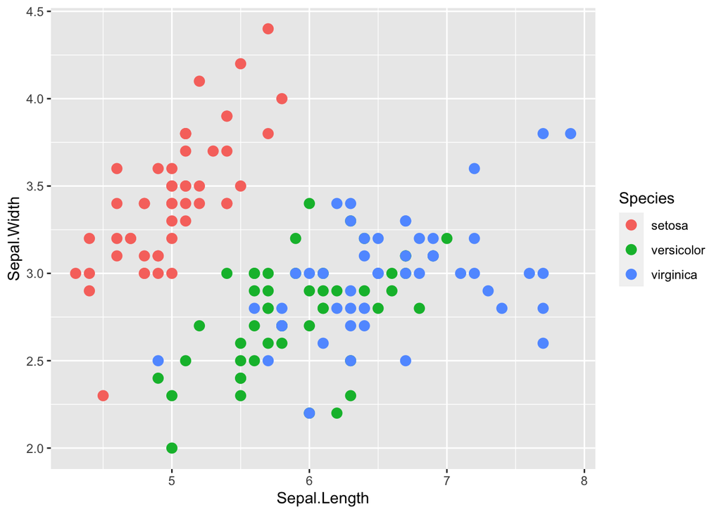

```r
iris%>%
    ggplot(aes(x = Sepal.Length, y = Sepal.Width, colour = Species))+
    geom_point(size = 3)
```

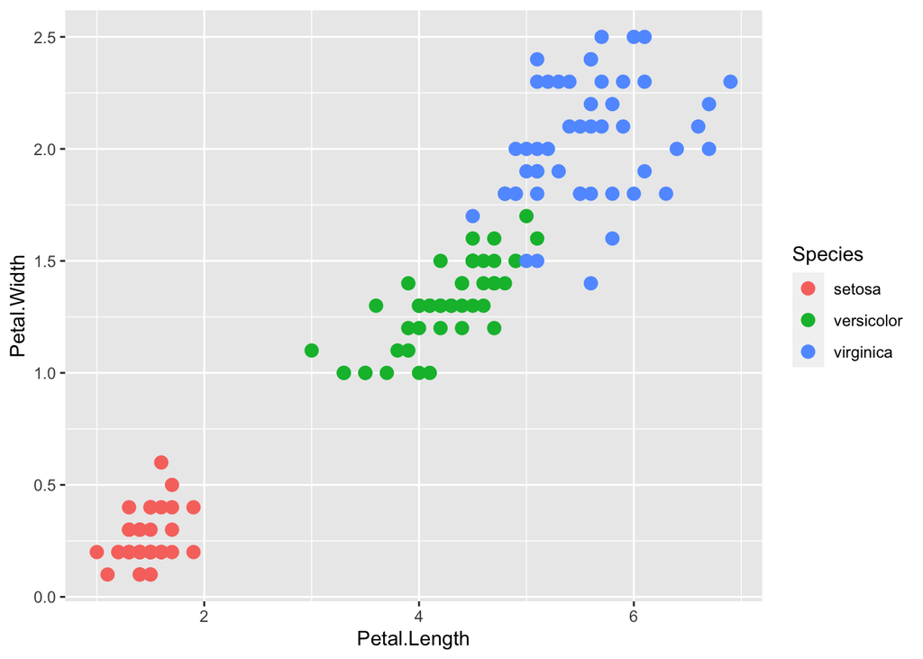

```r
iris%>%
    ggplot(aes(x = Petal.Length, y = Petal.Width, colour = Species))+
    geom_point(size = 3)
```